# Tugas Kuliah MPDW Pert 2

# Import Library dan Data

```r
library(readxl)
library(GGally)
library(psych)
library(car)
library(carData)
library(corrplot)
library(dplyr)
library(stargazer)
library(olsrr)
library(lmtest)
library(orcutt) #untuk membuat model regresi Cochrane-Orcutt
library(HoRM) #untuk membuat model regresi Hildreth-Lu
```

```r
df <- read_xlsx("C:/Users/camel/Downloads/IPM Kota Pekanbaru.xlsx")
df
```

```
## # A tibble: 15 × 2
##    Tahun   IPM
##    <dbl> <dbl>
##  1  2010  77.3
##  2  2011  77.7
##  3  2012  77.9
##  4  2013  78.2
##  5  2014  78.4
##  6  2015  79.3
##  7  2016  79.7
##  8  2017  80.0
##  9  2018  80.7
## 10  2019  81.4
## 11  2020  81.3
## 12  2021  81.6
## 13  2022  82.1
## 14  2023  82.4
## 15  2024  82.9
```

# Eksplorasi Data

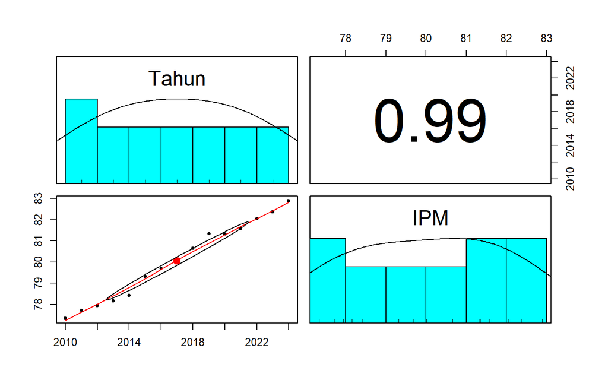

```r
pairs.panels(df)
```

```r
str(df)
```

```
## tibble [15 × 2] (S3: tbl_df/tbl/data.frame)
##  $ Tahun: num [1:15] 2010 2011 2012 2013 2014 ...
##  $ IPM  : num [1:15] 77.3 77.7 77.9 78.2 78.4 ...
```

```r
summary(df)
```

```
##      Tahun           IPM
##  Min.   :2010   Min.   :77.34
##  1st Qu.:2014   1st Qu.:78.29
##  Median :2017   Median :80.01
##  Mean   :2017   Mean   :80.06
##  3rd Qu.:2020   3rd Qu.:81.47
##  Max.   :2024   Max.   :82.89
```

```r
colSums(is.na(df))
```

```
## Tahun   IPM
##     0     0
```

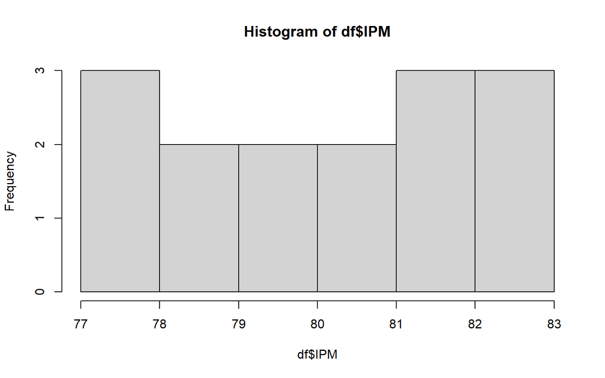

```r
hist(df$IPM)
```

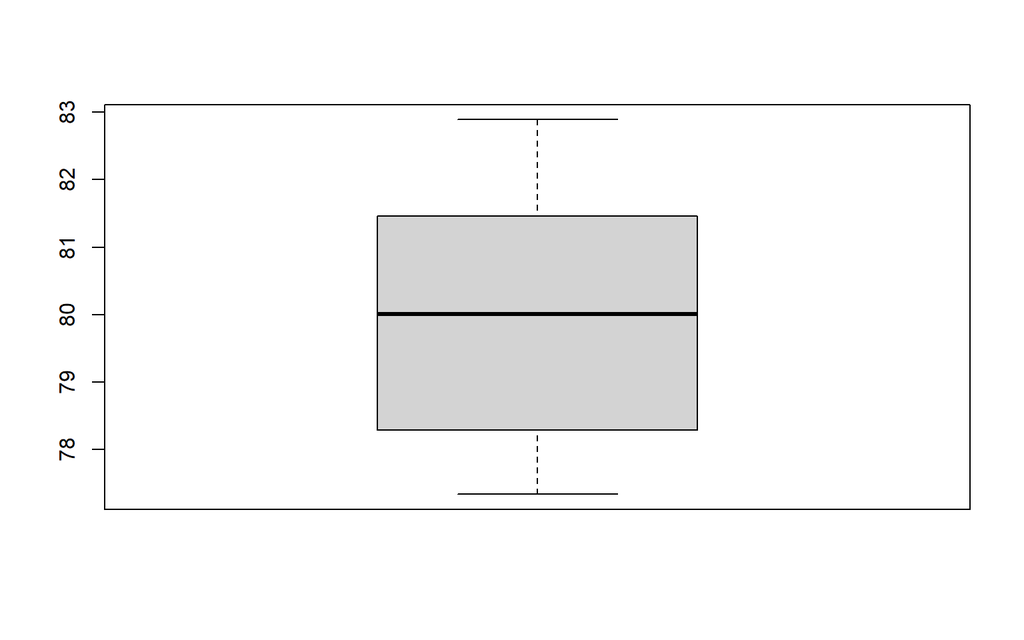

```r
boxplot(df$IPM)
```

# Regresi

```r
# Misalnya model linear regresi sederhana (ubah sesuai modelmu)
model <- lm(IPM ~ Tahun, data = df)   # atau IPM ~ variabel lain
summary(model)
```

```
##
## Call:
## lm(formula = IPM ~ Tahun, data = df)
##
## Residuals:
##      Min       1Q   Median       3Q      Max
## -0.40448 -0.09019 -0.03733  0.10081  0.47410
##
## Coefficients:
##               Estimate Std. Error t value Pr(>|t|)
## (Intercept) -747.49095   25.49032  -29.32 2.91e-13 ***
## Tahun          0.41029    0.01264   32.47 7.88e-14 ***
## ---
## Signif. codes:  0 '***' 0.001 '**' 0.01 '*' 0.05 '.' 0.1 ' ' 1
##
## Residual standard error: 0.2115 on 13 degrees of freedom
## Multiple R-squared:  0.9878, Adjusted R-squared:  0.9869
## F-statistic:  1054 on 1 and 13 DF,  p-value: 7.88e-14
```

## Asumsi Klasik

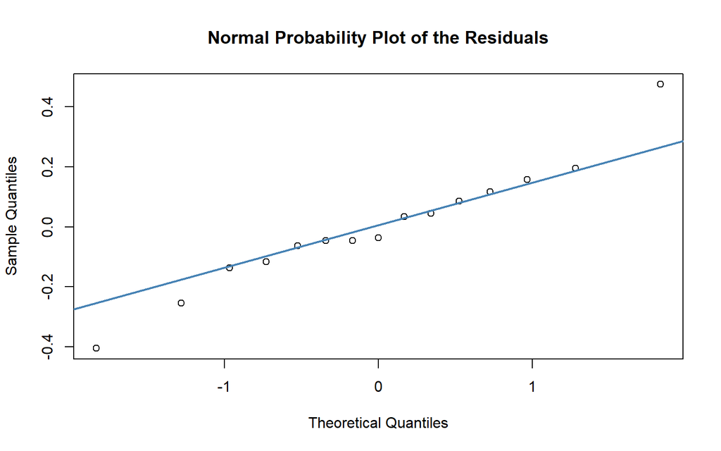

```r
# Residuals
resid <- residuals(model)
fitted <- fitted.values(model)

# 1. Normal Probability Plot (QQ Plot)
qqnorm(resid, main="Normal Probability Plot of the Residuals")
qqline(resid, col = "steelblue", lwd = 2)
```

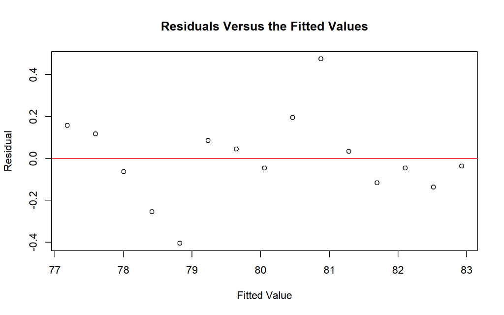

```r
# 2. Residuals vs Fitted
plot(fitted, resid,
     xlab="Fitted Value", ylab="Residual",
     main="Residuals Versus the Fitted Values")
abline(h=0, col="red")
```

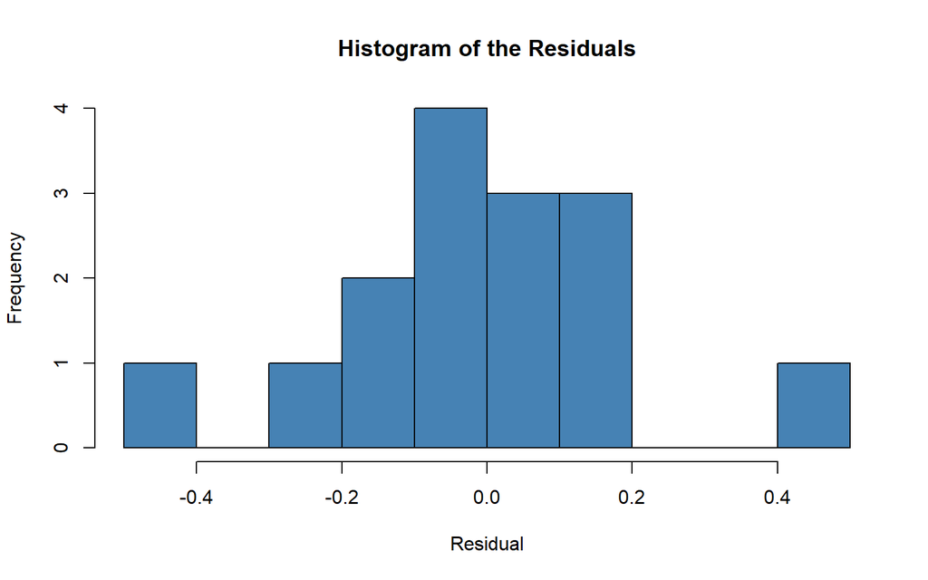

```r
# 3. Histogram Residuals
hist(resid, breaks=10, col="steelblue",
     main="Histogram of the Residuals", xlab="Residual")
```

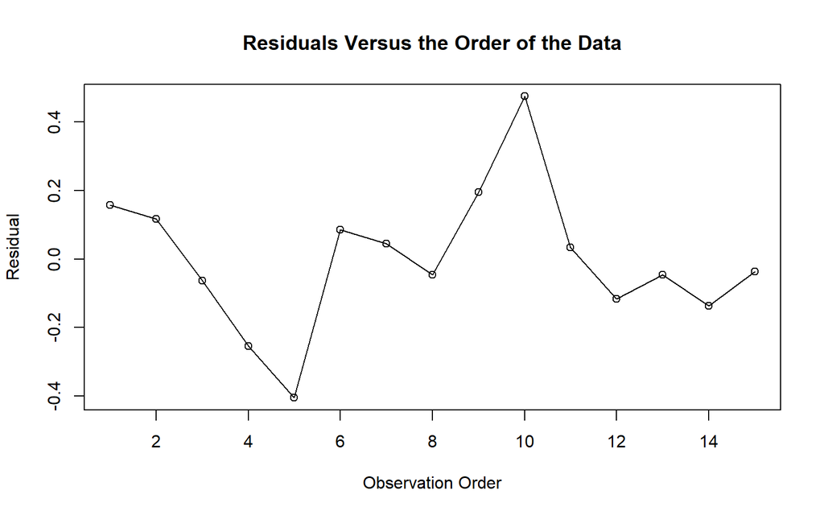

```r
# 4. Residuals vs Order
plot(resid, type="o",
     main="Residuals Versus the Order of the Data",
     xlab="Observation Order", ylab="Residual")
```

```r
#Melihat Sisaan Menyebar Normal/Tidak
#H0: sisaan mengikuti sebaran normal
#H1: sisaan tidak mengikuti sebaran normal
shapiro.test(resid)
```

```
##
##  Shapiro-Wilk normality test
##
## data:  resid
## W = 0.96624, p-value = 0.799
```

```r
ks.test(resid, "pnorm", mean=mean(resid), sd=sd(resid))
```

```
##
##  Exact one-sample Kolmogorov-Smirnov test
##
## data:  resid
## D = 0.11729, p-value = 0.9706
## alternative hypothesis: two-sided
```

Berdasarkan uji formal Saphiro-Wilk dan Kolmogorov-Smirnov didapatkan nilai *p-value* > $\alpha$ (5%). Artinya, cukup bukti untuk menyatakan sisaan berdistribusi normal.

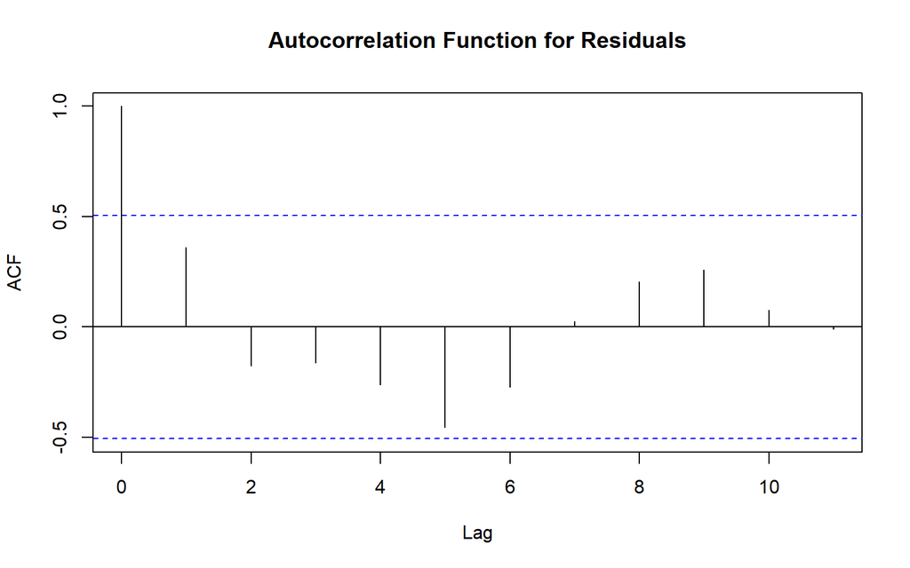

```r
# 5. Autocorrelation Function (ACF)
acf(resid, main="Autocorrelation Function for Residuals")
```

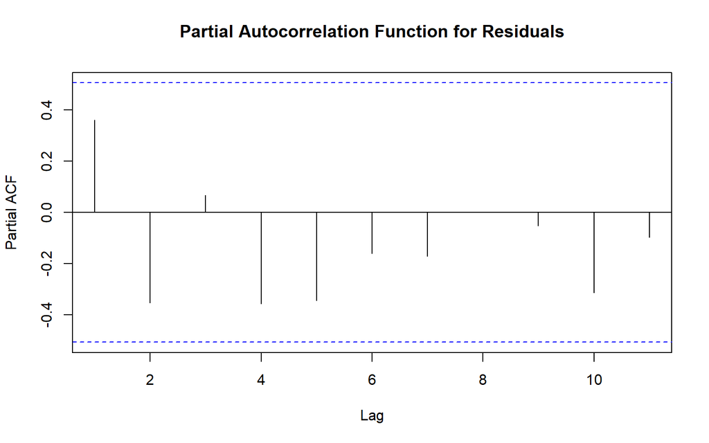

```r
# 6. Partial Autocorrelation Function (PACF)
pacf(resid, main="Partial Autocorrelation Function for Residuals")
```

Berdasarkan plot ACF dan PACF, terlihat semua dalam rentang batas dan tidak ada lag yang signifikan. Namun, untuk lebih memastikan akan dilakukan uji formal dengan uji Durbin Watson.

```r
#Deteksi autokorelasi dengan uji-Durbin Watson
#H0: tidak ada autokorelasi
#H1: ada autokorelasi
dwtest(model)
```

```
##
##  Durbin-Watson test
##
## data:  model
## DW = 1.2344, p-value = 0.02686
## alternative hypothesis: true autocorrelation is greater than 0
```

Berdasarkan hasil DW Test, didapatkan nilai $DW = 1.2344$ dan *p-value* = $0.02686$. Berdasarkan tabel Durbin-Watson diperoleh nilai $DL = 0.9771$ dan $DU = 1.331$. Nilai DW masih berada di antara nilai DL dan DU. Artinya, berada di daerah inkonklusif, tidak dapat dikatakan berada di daerah autokorelasi positif maupun bebas dari autokorelasi. Namun, dengan nilai *p-value* < 0.05 dapat disimpulkan bahwa tolak H0, cukup bukti mengatakan adanya autokorelasi. Oleh karena itu, diperlukan penangan autokorelasi. Penanganan yang akan digunakan menggunakan dua metode, yaitu Cochrane-Orcutt dan Hildret-Lu.

# Penanganan Autokorelasi

## Metode Cochrane-Orcutt

Penanganan metode Cochrane-Orcutt dapat dilakukan dengan bantuan packages Orcutt pada aplikasi `R` maupun secara manual. Berikut ini ditampilkan cara menggunakan bantuan `library` *packages* `Orcutt`.

```r
#Penanganan Autokorelasi Cochrane-Orcutt
modelCO<-cochrane.orcutt(model)
modelCO
```

```
## Cochrane-orcutt estimation for first order autocorrelation
##
## Call:
## lm(formula = IPM ~ Tahun, data = df)
##
##  number of interaction: 6
##  rho 0.359868
##
## Durbin-Watson statistic
## (original):    1.23438 , p-value: 2.686e-02
## (transformed): 1.79204 , p-value: 2.311e-01
##
##  coefficients:
## (Intercept)       Tahun
## -762.396132    0.417662
```

```r
#Rho optimum
rho<- modelCO$rho
rho
```

```
## [1] 0.3598682
```

Selanjutnya akan dilakukan transformasi secara manual dengan syntax berikut ini.

```r
IPM <- df$IPM
Tahun <- df$Tahun
```

```r
IPM[-1]
```

```
##  [1] 77.71 77.94 78.16 78.42 79.32 79.69 80.01 80.66 81.35 81.32 81.58 82.06
## [13] 82.38 82.89
```

```r
#Transformasi Manual
IPM.trans<- IPM[-1]-IPM[-15]*rho
Tahun.trans<- Tahun[-1]-Tahun[-15]*rho
modelCOmanual<- lm(IPM.trans~Tahun.trans)
summary(modelCOmanual)
```

```
##
## Call:
## lm(formula = IPM.trans ~ Tahun.trans)
##
## Residuals:
##      Min       1Q   Median       3Q      Max
## -0.28432 -0.13378 -0.03047  0.08551  0.40921
##
## Coefficients:
##               Estimate Std. Error t value Pr(>|t|)
## (Intercept) -488.03401   26.58968  -18.35 3.79e-10 ***
## Tahun.trans    0.41766    0.02058   20.29 1.18e-10 ***
## ---
## Signif. codes:  0 '***' 0.001 '**' 0.01 '*' 0.05 '.' 0.1 ' ' 1
##
## Residual standard error: 0.1987 on 12 degrees of freedom
## Multiple R-squared:  0.9717, Adjusted R-squared:  0.9693
## F-statistic: 411.8 on 1 and 12 DF,  p-value: 1.178e-10
```

```r
#Mencari Penduga Koefisien Regresi setelah Transformasi ke Persamaan Awal
b0bintang <- modelCOmanual$coefficients[-2]
b0 <- b0bintang/(1-rho)
b1 <- modelCOmanual$coefficients[-1]
b0
```

```
## (Intercept)
##   -762.3961
```

```r
b1
```

```
## Tahun.trans
##   0.4176622
```

Hasil perhitungan koefisien regresi tersebut akan menghasilkan hasil yang sama dengan model yang dihasilkan menggunakan *packages*.

## Metode Hildreth-Lu

Penanganan kedua adalah menggunakan metode Hildreth-Lu. Metode ini akan mencari nilai SSE terkecil dan dapat dicari secara manual maupun menggunakan packages. Jika menggunakan packages, gunakan `library` *packages* `HORM`.

```r
library(HoRM)

# ambil y dan x (satu prediktor saja)
y <- df$IPM
x <- df$Tahun

# grid search rho 0–0.9
r <- seq(0, 0.9, by = 0.1)
tab <- data.frame(
  rho = r,
  SSE = sapply(r, function(rr) deviance(hildreth.lu(y, x, rr)))
)

tab            # tabel rho vs SSE
```

```
##    rho       SSE
## 1  0.0 0.5489842
## 2  0.1 0.5130697
## 3  0.2 0.4887454
## 4  0.3 0.4760114
## 5  0.4 0.4748677
## 6  0.5 0.4853142
## 7  0.6 0.5073509
## 8  0.7 0.5409779
## 9  0.8 0.5861952
## 10 0.9 0.6430027
```

```r
rho_hat <- tab$rho[which.min(tab$SSE)]   # rho terbaik
fit_hl  <- hildreth.lu(y, x, rho_hat)    # model final
summary(fit_hl)
```

```
##
## Call:
## lm(formula = y ~ x)
##
## Residuals:
##      Min       1Q   Median       3Q      Max
## -0.27419 -0.13352 -0.02883  0.07979  0.40159
##
## Coefficients:
##               Estimate Std. Error t value Pr(>|t|)
## (Intercept) -457.93677   26.61723  -17.20 8.03e-10 ***
## x              0.41807    0.02198   19.02 2.51e-10 ***
## ---
## Signif. codes:  0 '***' 0.001 '**' 0.01 '*' 0.05 '.' 0.1 ' ' 1
##
## Residual standard error: 0.1989 on 12 degrees of freedom
## Multiple R-squared:  0.9679, Adjusted R-squared:  0.9652
## F-statistic: 361.7 on 1 and 12 DF,  p-value: 2.506e-10
```

```r
#Penanganan Autokorelasi Hildreth lu
# Hildreth-Lu
hildreth.lu.func<- function(r, model){
  x <- model.matrix(model)[,-1]
  y <- model.response(model.frame(model))
  n <- length(y)
  t <- 2:n
  y <- y[t]-r*y[t-1]
  x <- x[t]-r*x[t-1]

  return(lm(y~x))
}

#Pencariab rho yang meminimumkan SSE
r <- c(seq(0.1,0.9, by= 0.1))
tab <- data.frame("rho" = r, "SSE" = sapply(r, function(i){deviance(hildreth.lu.func(i, model))}))
round(tab, 4)
```

```
##   rho    SSE
## 1 0.1 0.5131
## 2 0.2 0.4887
## 3 0.3 0.4760
## 4 0.4 0.4749
## 5 0.5 0.4853
## 6 0.6 0.5074
## 7 0.7 0.5410
## 8 0.8 0.5862
## 9 0.9 0.6430
```

```r
#Rho optimal di sekitar 0.4
rOpt <- seq(0.3,0.5, by= 0.001)
tabOpt <- data.frame("rho" = rOpt, "SSE" = sapply(rOpt, function(i){deviance(hildreth.lu.func(i, model))}))
head(tabOpt[order(tabOpt$SSE),])
```

```
##      rho       SSE
## 61 0.360 0.4739343
## 60 0.359 0.4739348
## 62 0.361 0.4739351
## 59 0.358 0.4739364
## 63 0.362 0.4739370
## 58 0.357 0.4739391
```

```r
#Rho optimal di sekitar 0.4
rOpt <- seq(0.3,0.4, by= 0.0001)
tabOpt <- data.frame("rho" = rOpt, "SSE" = sapply(rOpt, function(i){deviance(hildreth.lu.func(i, model))}))
head(tabOpt[order(tabOpt$SSE),])
```

```
##        rho       SSE
## 600 0.3599 0.4739343
## 599 0.3598 0.4739343
## 601 0.3600 0.4739343
## 598 0.3597 0.4739344
## 602 0.3601 0.4739344
## 597 0.3596 0.4739344
```

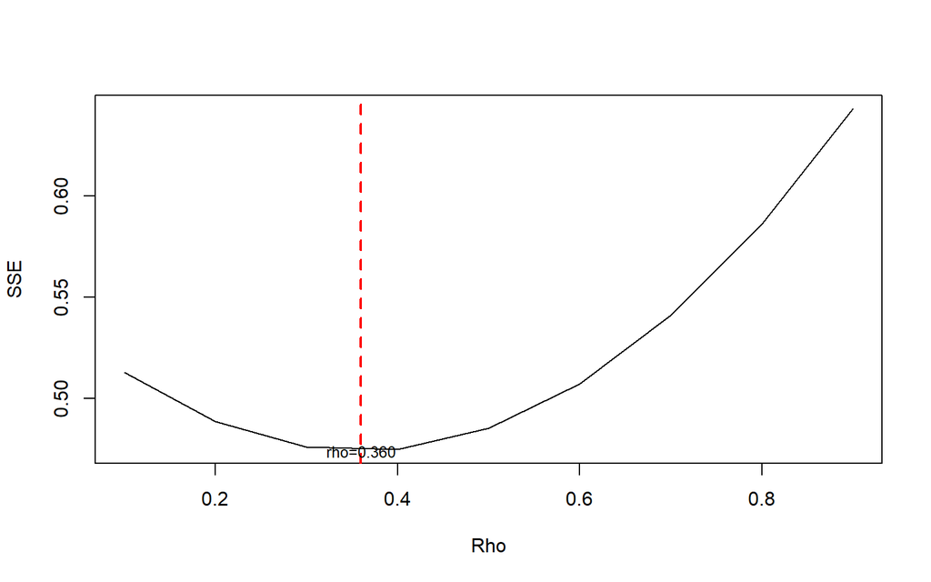

```r
#Grafik SSE optimum
par(mfrow = c(1,1))
plot(tab$SSE ~ tab$rho , type = "l", xlab = "Rho", ylab = "SSE")
abline(v = tabOpt[tabOpt$SSE==min(tabOpt$SSE),"rho"], lty = 2, col="red",lwd=2)
text(x=0.360, y=0.4739343, labels = "rho=0.360", cex = 0.8)
```

Perhitungan yang dilakukan aplikasi `R` menunjukkan bahwa nilai $ρ$ optimum, yaitu saat SSE terkecil terdapat pada nilai $ρ=0.360$. Hal tersebut juga ditunjukkan pada plot. Selanjutnya, model dapat didapatkan dengan mengevaluasi nilai $ρ$ ke dalam fungsi `hildreth.lu.func`, serta dilanjutkan dengan pengujian autokorelasi dengan uji Durbin-Watson. Namun, setelah pengecekan tersebut tidak lupa koefisien regresi tersebut digunakan untuk transformasi balik. Persamaan hasil transformasi itulah yang menjadi persamaan sesungguhnya.

```r
#Model terbaik
modelHL <- hildreth.lu.func(0.360, model)
summary(modelHL)
```

```
##
## Call:
## lm(formula = y ~ x)
##
## Residuals:
##      Min       1Q   Median       3Q      Max
## -0.28429 -0.13378 -0.03047  0.08549  0.40919
##
## Coefficients:
##               Estimate Std. Error t value Pr(>|t|)
## (Intercept) -487.93516   26.58969  -18.35 3.80e-10 ***
## x              0.41766    0.02059   20.29 1.18e-10 ***
## ---
## Signif. codes:  0 '***' 0.001 '**' 0.01 '*' 0.05 '.' 0.1 ' ' 1
##
## Residual standard error: 0.1987 on 12 degrees of freedom
## Multiple R-squared:  0.9717, Adjusted R-squared:  0.9693
## F-statistic: 411.6 on 1 and 12 DF,  p-value: 1.181e-10
```

```r
#Transformasi Balik
cat("y = ", coef(modelHL)[1]/(1-0.360), "+", coef(modelHL)[2],"x", sep = "")
```

```
## y = -762.3987+0.4176635x
```

Setelah dilakukan tranformasi balik, didapatkan model dengan metode Hildreth-Lu sebagai berikut.
$$y_i=-762.3987+0.4176635x_t$$

```r
#Deteksi autokorelasi
dwtest(modelHL)
```

```
##
##  Durbin-Watson test
##
## data:  modelHL
## DW = 1.7922, p-value = 0.2312
## alternative hypothesis: true autocorrelation is greater than 0
```

Hasil uji Durbin-Watson juga menunjukkan bawah nilai DW sebesar $1.7922$ berada pada selang daerah tidak ada autokorelasi, yaitu pada rentang DU < DW < 4-DU atau $1.331 < DW < 2.669$. Hal tersebut juga didukung oleh *p-value* sebesar $0.2312$, di mana *p-value* > $\alpha$=5%. Artinya tak tolak $H_0$ atau belum cukup bukti menyatakan bahwa ada autokorelasi dalam data nilai IPM dengan metode Hildreth-Lu pada taraf nyata 5%.

Terakhir, akan dibandingkan nilai SSE dari ketiga metode (metode awal, metode Cochrane-Orcutt, dan Hildreth-Lu).

```r
#Perbandingan
sseModelawal <- anova(model)$`Sum Sq`[-1]
sseModelCO <- anova(modelCOmanual)$`Sum Sq`[-1]
sseModelHL <- anova(modelHL)$`Sum Sq`[-1]
mseModelawal <- sseModelawal/length(IPM)
mseModelCO <- sseModelCO/length(IPM)
mseModelHL <- sseModelHL/length(IPM)
akurasi <- matrix(c(sseModelawal,sseModelCO,sseModelHL,
                    mseModelawal,mseModelCO,mseModelHL),nrow=2,ncol=3,byrow = T)
colnames(akurasi) <- c("Model Awal", "Model Cochrane-Orcutt", "Model Hildreth-Lu")
row.names(akurasi) <- c("SSE","MSE")
akurasi
```

```
##     Model Awal Model Cochrane-Orcutt Model Hildreth-Lu
## SSE  0.5813505            0.47393433        0.47393434
## MSE  0.0387567            0.03159562        0.03159562
```

Berdasarkan hasil tersebut dapat diketahui bahwa hasil penanganan autokorelasi dengan metode Cochrane-Orcutt dan Hildreth-Lu memiliki SSE yang hampir sama, sebesar $0.4739343$ dan lebih baik dibandingkan model awal ketika autokorelasi masih terjadi, yaitu sebesar $0.5813505$.

# Simpulan

Autokorelasi yang terdapat pada data **IPM Kota Pekanbaru Tahun 2010-2024** terjadi akibat adanya korelasi di antara unsur penyusunnya. Indikator IPM yang erat hubungannya dengan perekonomian sangat rawan menjadi penyebab adanya autokorelasi. Adanya autokorelasi menyebabkan model regresi kurang baik karena akan meingkatkan galatnya. Autokorelasi dapat dideteksi secara eksploratif melalui plot sisaan, ACF, dan PACF, serta dengan uji formal Durbin-Watson. Namun, autokorelasi tersebut dapat ditangani dengan metode Cochrane-Orcutt dan Hildreth-Lu. Kedua metode menghasilkan nilai SSE yang sama, artinya keduanya baik untuk digunakan.